# Sales forecasting using ML

## Dataset loading and preparation

In this exercise we will see how fbprophet’s performance lines up beside other baseline models. First off lets import some packages we will use. load the data and see how it is structured.

Let’s load the data file from the data folder. It has 3 columns: an index, one denoting date and hour, and the other the number of hot dogs sold in this mistery station. The column names are featured in the first row. We should also make sure the date and hour handled correctly.

```r
hd_sales <- read.csv(file = "data/hourly_combined_hd_sales_B.csv", header = TRUE) %>%
  mutate(SES_TRX_DATEHOUR = as.POSIXct(SES_TRX_DATEHOUR, format = "%Y-%m-%d %H:%M:%S"))
```

Let’s see how the dataset is structured:

```r
hd_sales %>% head(30)
```

|  | INDEX | SES_TRX_DATEHOUR | NUMBER_OF_PRODUCT_SOLD |
| --- | --- | --- | --- |
| 1 | 0 | 2020-09-01 01:00:00 | 1 |
| 2 | 1 | 2020-09-01 03:00:00 | 1 |
| 3 | 2 | 2020-09-01 05:00:00 | 8 |
| 4 | 3 | 2020-09-01 06:00:00 | 3 |
| 5 | 4 | 2020-09-01 07:00:00 | 8 |
| 6 | 5 | 2020-09-01 08:00:00 | 16 |
| 7 | 6 | 2020-09-01 09:00:00 | 5 |
| 8 | 7 | 2020-09-01 10:00:00 | 4 |
| 9 | 8 | 2020-09-01 11:00:00 | 8 |
| 10 | 9 | 2020-09-01 12:00:00 | 10 |

[output cut: 20 more lines]

We can see that there is a problem: only hours with sales are featured. It would be a lot of additional work to handle this in later steps, so let’s add the missing hours with 0 sales. We do this as follows: - we create a complete list of dates between min and max date - add 1-24 hours to all dates - outer join to add missing observations (there is no outer join in tidyverse) - fill sold with zeros where we see NA (ergo there was no match in the data for the given hour) - we will drop index, since it is not needed

|  | SES_TRX_DATEHOUR | NUMBER_OF_PRODUCT_SOLD |
| --- | --- | --- |
| 1 | 2020-09-01 01:00:00 | 1 |
| 2 | 2020-09-01 02:00:00 | 0 |
| 3 | 2020-09-01 03:00:00 | 1 |
| 4 | 2020-09-01 04:00:00 | 0 |
| 5 | 2020-09-01 05:00:00 | 8 |
| 6 | 2020-09-01 06:00:00 | 3 |
| 7 | 2020-09-01 07:00:00 | 8 |
| 8 | 2020-09-01 08:00:00 | 16 |
| 9 | 2020-09-01 09:00:00 | 5 |
| 10 | 2020-09-01 10:00:00 | 4 |

[output cut: 20 more lines]

### 1st task

What is the percentage of zero sales hours through all observations?

## Data analysis

Let’s see how sales looks over time.

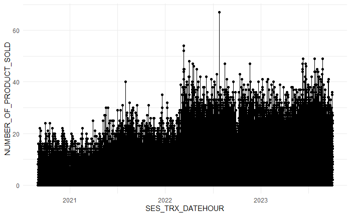

Not much to see with hourly plotting. Lets create a daily aggregate for analysis and visualize that.

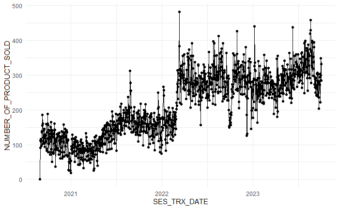

Much better. Now we see some local volatility, which can be some weekly periodicity and a regime shift around february of ’22 as well as some local trends.

Let’s see that weekly periodicity! We can look at the distribution of sales by weekday.

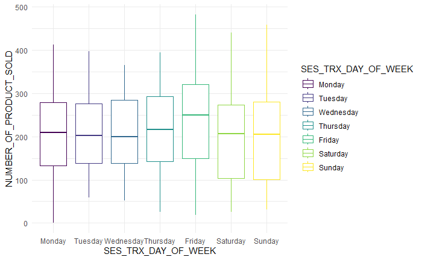

But as we see this gets blurred by the trends and larger periods. The only ting that is standing out is that Friday seems to outperform most of the others. Lets prepare relative performance on a weekly level!

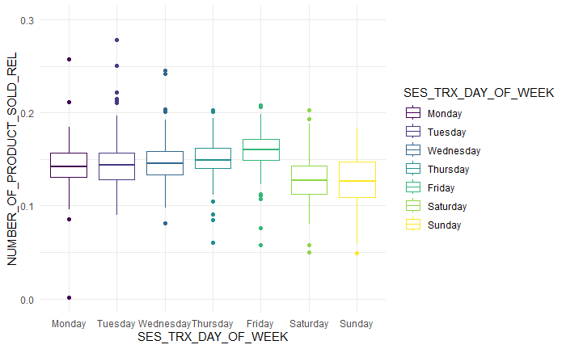

Now we see the weekly pattern much stronger: a gradual increase in sales starting from Monday through Friday, then lower relative weekend sales.

### 2nd task

Based on what we have learned before, let’s see how the daily periodicity looks like!

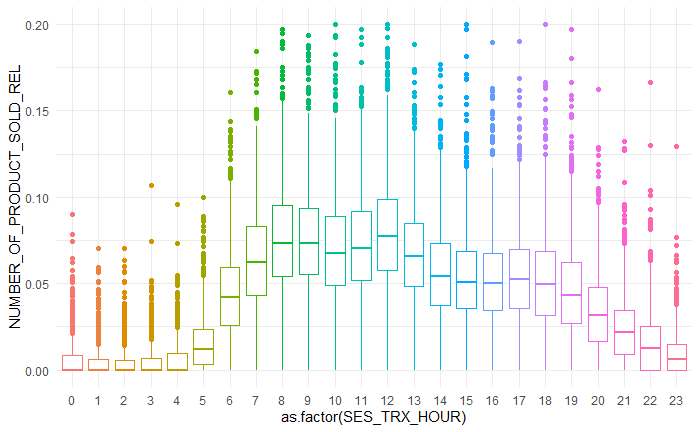

We can see some local peaks around main mealtimes.

## Preparation for simulations

```r
training_days <- 365
forecast_days <- 7

model_ranges <- tibble(
  name = c("Christmas","Late winter","Easter","Early summer","Late summer"),
  start = as.Date(c("2022-12-22","2023-02-23","2023-04-06","2023-06-08","2023-08-17"))) %>%
  mutate(end = start + days(forecast_days)) %>%
  #mutate(train = map(start, function(x)filter(hd_sales_full, as.Date(SES_TRX_DATEHOUR) < x))) %>%
  mutate(train = map(start, function(x)filter(hd_sales_full, between(as.Date(SES_TRX_DATEHOUR), x - days(training_days), x)))) %>%
  mutate(target = map2(start, end, function(x,y)filter(hd_sales_full, between(as.Date(SES_TRX_DATEHOUR), x, y))))
model_ranges
```

| name | start | end | train | target |
| --- | --- | --- | --- | --- |
| Christmas | 2022-12-22 | 2022-12-29 |  |  |
| Late winter | 2023-02-23 | 2023-03-02 |  |  |
| Easter | 2023-04-06 | 2023-04-13 |  |  |
| Early summer | 2023-06-08 | 2023-06-15 |  |  |
| Late summer | 2023-08-17 | 2023-08-24 |  |  |

## MA model

As discussed, the main symmetries of the generator process we would like to adhere to are daily and weekly periodicity. A simple heuristic averaging model would look something like this:

where $x\left(D,H\right)$ refers to total sales at the $H$ hour of day $D$, $W$ refers to the (maximum $N$) number of weeks to look back to when creating the average: $\chi\left(D,H,N\right)$. Simply put we take the last N weeks sales average from the same weekday’s same hour. This is an edge case of the generic moving average (MA) model of the ARIMA family, that forces things like equal weighting of observations.

**Question:** Will taking past observations with equal weighting ($\theta_n$ in MA models) *strengthen* or *dampen* the effect of linear trends in recent observations on our estimate?

Let’s formulate this into a function!

```r
calcWeeklyAverage <- function(training, target_datetimes, N){
  training_upd <- training
  target_datetimes_sorted <- sort(target_datetimes)
  for(i in 1:length(target_datetimes_sorted)){
    #get all dates referring to the relevant history
    past <- target_datetimes_sorted[i] - weeks(1:N)
    #get all relevant observations from the training data, calculate estimate (mean)
    estimate <- training_upd %>%
      filter(SES_TRX_DATEHOUR %in% past) %>%
      pull(NUMBER_OF_PRODUCT_SOLD) %>%
      mean()
    #update the training dataset so we can estimate for more than 1 week into the future
    training_upd <- training_upd %>% add_row(SES_TRX_DATEHOUR = target_datetimes_sorted[i], NUMBER_OF_PRODUCT_SOLD = estimate)
  }
  return(training_upd %>% tail(length(target_datetimes)))
}
```

This model has one parameter, that is to see how many weeky we want to look into the past, namely $N$. Let’s create model outputs for $N=4$ and $N=12$. This will take some time.

```r
model_ranges_avg_calced <- model_ranges %>%
  mutate(model_avg_N_4 = map2(train, target, function(x,y)calcWeeklyAverage(x, y$SES_TRX_DATEHOUR, 4))) %>%
  mutate(model_avg_N_12 = map2(train, target, function(x,y)calcWeeklyAverage(x, y$SES_TRX_DATEHOUR, 12)))
```

Let’s add some visualization, concentrate on the last week of predicition which is usally how it happens in production.

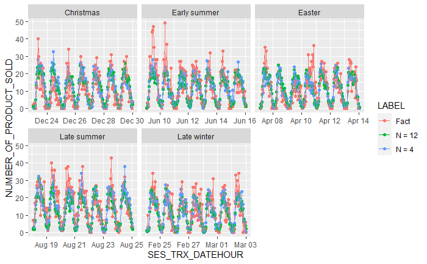

```r
model_ranges_avg_calced %>%
  mutate(toplot = map2(train, target, function(x,y)bind_rows(x %>% mutate(LABEL = "Train"), y %>% mutate(LABEL = "Fact")))) %>%
  mutate(toplot = map2(toplot, model_avg_N_4, function(x,y)bind_rows(x, y %>% mutate(LABEL = "N = 4")))) %>%
  mutate(toplot = map2(toplot, model_avg_N_12, function(x,y)bind_rows(x, y %>% mutate(LABEL = "N = 12")))) %>%
  mutate(toplot = map2(toplot, name, function(x,y)mutate(x, SECTION = y))) %>%
  mutate(toplot = map(toplot, function(x)filter(x, SES_TRX_DATEHOUR > (max(x$SES_TRX_DATEHOUR) - weeks(1))))) %>%
  pull(toplot) %>%
  bind_rows() %>%
  ggplot(aes(x = SES_TRX_DATEHOUR, y = NUMBER_OF_PRODUCT_SOLD, colour = LABEL)) +
  facet_wrap(vars(SECTION), scales = "free_x") +
  geom_point() +
  geom_line()
```

So far this looks pretty promising, although it is quite hard to decide which model is better. Let’s calculate some aggregate errors, like mean absolute error (MAE) and root mean square error (RMSE) after rounding the results.

```r
errors_avg_model <- model_ranges_avg_calced %>%
  mutate(mae.n4 = map2(target, model_avg_N_4,
                          function(x,y)left_join(x, y %>% rename(NUMBER_OF_PRODUCT_PRED = NUMBER_OF_PRODUCT_SOLD), by = "SES_TRX_DATEHOUR") %>%
                            mutate(ae = abs(round(NUMBER_OF_PRODUCT_PRED) - NUMBER_OF_PRODUCT_SOLD)) %>%
                            pull(ae) %>%
                            mean()) %>% unlist()) %>%
  mutate(mae.n12 = map2(target, model_avg_N_12,
                          function(x,y)left_join(x, y %>% rename(NUMBER_OF_PRODUCT_PRED = NUMBER_OF_PRODUCT_SOLD), by = "SES_TRX_DATEHOUR") %>%
                            mutate(ae = abs(round(NUMBER_OF_PRODUCT_PRED) - NUMBER_OF_PRODUCT_SOLD)) %>%
                            pull(ae) %>%
                            mean()) %>% unlist()) %>%
  mutate(rmse.n4 = map2(target, model_avg_N_4,
                          function(x,y)left_join(x, y %>% rename(NUMBER_OF_PRODUCT_PRED = NUMBER_OF_PRODUCT_SOLD), by = "SES_TRX_DATEHOUR") %>%
                            mutate(se = (round(NUMBER_OF_PRODUCT_PRED) - NUMBER_OF_PRODUCT_SOLD)^2) %>%
                            pull(se) %>%
                            {sqrt(mean(.))}) %>% unlist()) %>%
  mutate(rmse.n12 = map2(target, model_avg_N_12,
                          function(x,y)left_join(x , y %>% rename(NUMBER_OF_PRODUCT_PRED = NUMBER_OF_PRODUCT_SOLD), by = "SES_TRX_DATEHOUR") %>%
                            mutate(se = (round(NUMBER_OF_PRODUCT_PRED) - NUMBER_OF_PRODUCT_SOLD)^2) %>%
                            pull(se) %>%
                            {sqrt(mean(.))}) %>% unlist()) %>%
  select(name, mae.n4 : rmse.n12)

errors_avg_model
```

| name | mae.n4 | mae.n12 | rmse.n4 | rmse.n12 |
| --- | --- | --- | --- | --- |
| Christmas | 4.755208 | 4.807292 | 6.367643 | 6.117342 |
| Late winter | 4.265625 | 4.067708 | 5.851015 | 5.501420 |
| Easter | 4.583333 | 4.541667 | 6.715964 | 6.411253 |
| Early summer | 4.843750 | 4.364583 | 6.830538 | 6.514407 |
| Late summer | 5.156250 | 5.067708 | 6.973163 | 6.809537 |

We can also plot them.

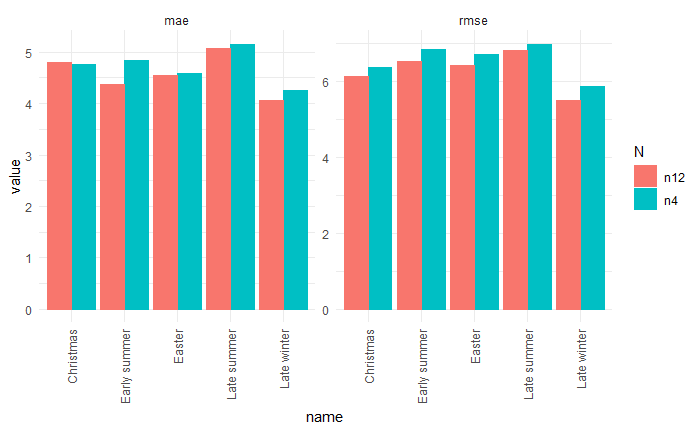

```r
errors_avg_model %>%
  pivot_longer(mae.n4 : rmse.n12, names_to = "memod", values_to = "value") %>%
  separate(memod, into = c("measure", "N")) %>%
  ggplot(aes(x = name, y = value, colour = N, fill = N)) +
  facet_wrap(vars(measure), scales = "free_y") +
  geom_bar(stat="identity", position=position_dodge()) +
  scale_x_discrete(guide = guide_axis(angle = 90)) +
  theme_minimal()
```

## Facebook Prophet model

You can access the documentation of the prophet model [here.](https://facebook.github.io/prophet/docs/quick_start.html#r-api)

```r
test_set_no <- 1

train <- model_ranges$train[[test_set_no]] %>%
  rename(ds = SES_TRX_DATEHOUR) %>%
  rename(y = NUMBER_OF_PRODUCT_SOLD)
m1_prefit <- prophet(yearly.seasonality = FALSE) %>%
  add_country_holidays('HU')
m1 <- m1_prefit %>%
  fit.prophet(train)
```

Let’s see if the holidays we are looking for are included (Karácsony, Húsvét).

```r
m1$train.holiday.names
```

```
 [1] "Ujev"                           "Nemzeti unnep"                  "Nagypentek"                     "Husvet"
 [5] "Husvet Hetfo"                   "A Munka unnepe"                 "Punkosd"                        "Punkosdhetfo"
 [9] "Az allamalapitas unnepe"        "Mindenszentek"                  "Szenteste"                      "Karacsony"
[13] "Karacsony masnapja"             "Nemzeti unnep elotti pihenonap" "Mindenszentek elotti pihenonap"
```

What about the results?

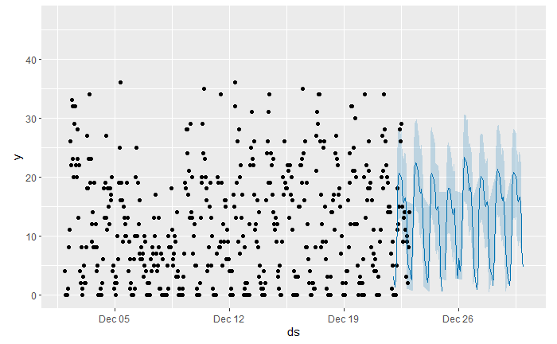

```r
future <- model_ranges$target[[test_set_no]] %>%
  rename(ds = SES_TRX_DATEHOUR) %>%
  select(ds)
fcst <- predict(m1, future)
plot(m1, fcst) + xlim(max(future$ds) - weeks(4), max(future$ds)) + ylim(0, max(fcst$yhat)*2)
```

Looks OK, let’s see the periodicities!

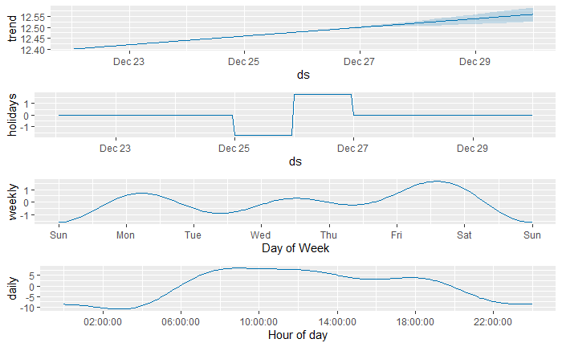

```r
prophet_plot_components(m1, fcst)
```

We can see: - an increasing (but not too aggressive) trend - the two holidays showing up - a weekly seasonality that reproduces what we have seen in our analysis - an intraday periodicity that also seem to match our earlier observation

Let’s eat the pudding and check MAE and RMSE

```r
model_ranges$target[[test_set_no]] %>%
   left_join(fcst %>% select(ds,yhat), by = join_by(SES_TRX_DATEHOUR == ds)) %>%
   drop_na() %>%
   mutate(ae = abs(NUMBER_OF_PRODUCT_SOLD-yhat)) %>%
   mutate(se = (NUMBER_OF_PRODUCT_SOLD-yhat)^2) %>%
   select(-SES_TRX_DATEHOUR) %>%
   {setNames(c(mean(.$ae),sqrt(mean(.$se))), c("MAE","RMSE"))}
```

```
     MAE     RMSE
5.058316 6.286207
```

Funnily enough this (uncallibrated!) model more or less performs similarly to the average model. But remember: we haven’t set up any parameters! And prophet has many… see [here.](https://facebook.github.io/prophet/docs/quick_start.html#r-api)

### 2nd task

Play around with the following parameters, train the model and see if you can decrease the error:

- set the growth to logistic
- seasonality to multiplicative
- decrease ammount of changepoint regularisation compared to the default (you have to figure out which variable I am thinking of)
- and whatever you may change

You can run the boxes below to check the results.

How does it look?

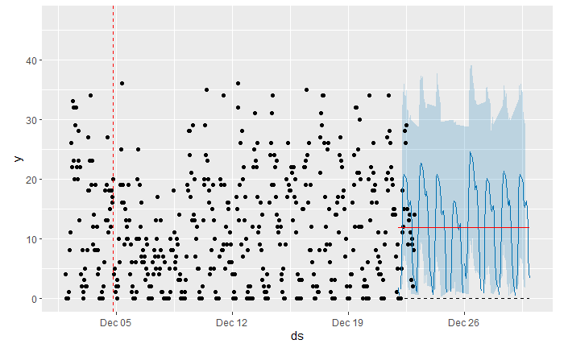

```r
plot(m2, fcst2) + xlim(max(future$ds) - weeks(4), max(future$ds))  + ylim(0, max(fcst$yhat)*2) + add_changepoints_to_plot(m2)
```

```r
#plot(m2, fcst2) + add_changepoints_to_plot(m2)
```

Check out the components!

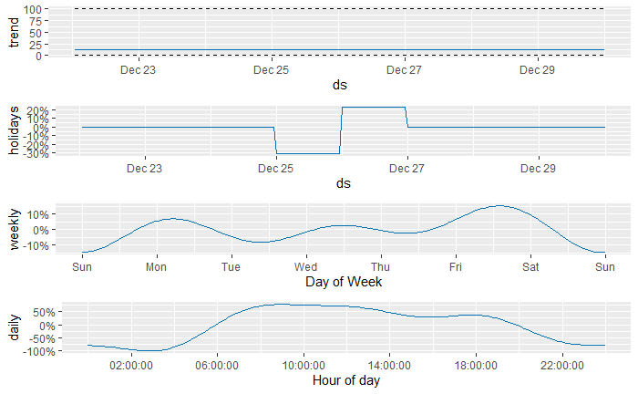

```r
prophet_plot_components(m2, fcst2)
```

Let’s eat the pudding and check MAE and RMSE

```r
model_ranges$target[[test_set_no]] %>%
   left_join(fcst2 %>% select(ds,yhat), by = join_by(SES_TRX_DATEHOUR == ds)) %>%
   drop_na() %>%
   mutate(ae = abs(NUMBER_OF_PRODUCT_SOLD-yhat)) %>%
   mutate(se = (NUMBER_OF_PRODUCT_SOLD-yhat)^2) %>%
   select(-SES_TRX_DATEHOUR) %>%
   {setNames(c(mean(.$ae),sqrt(mean(.$se))), c("MAE","RMSE"))}
```

```
     MAE     RMSE
4.882683 6.179966
```

### 3rd task

How does it look?

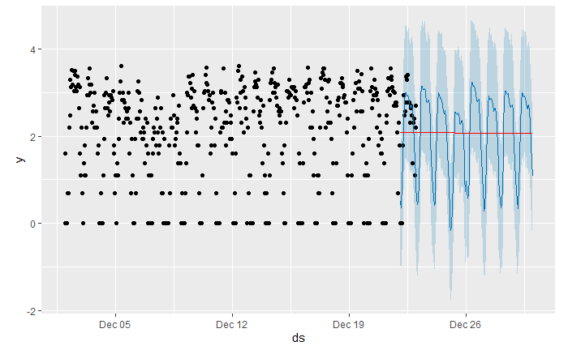

```r
plot(m3, fcst3) + xlim(max(future$ds) - weeks(4), max(future$ds))  + add_changepoints_to_plot(m3)
```

Check out the components!

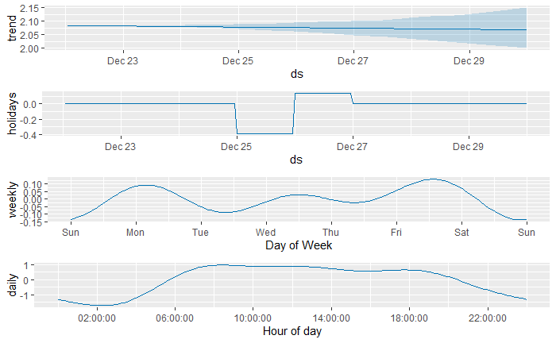

```r
prophet_plot_components(m3, fcst3)
```

```r
model_ranges$target[[test_set_no]] %>%
   left_join(fcst3 %>% select(ds,yhat) %>% mutate(yhat = exp(yhat)), by = join_by(SES_TRX_DATEHOUR == ds)) %>%
   drop_na() %>%
   mutate(ae = abs(NUMBER_OF_PRODUCT_SOLD-yhat)) %>%
   mutate(se = (NUMBER_OF_PRODUCT_SOLD-yhat)^2) %>%
   select(-SES_TRX_DATEHOUR) %>%
   {setNames(c(mean(.$ae),sqrt(mean(.$se))), c("MAE","RMSE"))}
```

```
     MAE     RMSE
4.478456 5.826300
```

### Now lets run all these models and compare them

```r
model_ranges_prophet_calced <- model_ranges %>%
  mutate(model_fbp_m1 = map2(train, target, function(x,y)predict(
    fit.prophet(m1_prefit, x %>% rename(ds = SES_TRX_DATEHOUR, y = NUMBER_OF_PRODUCT_SOLD)),
    y %>% rename(ds = SES_TRX_DATEHOUR) %>% select(ds)))) %>%
  mutate(model_fbp_m2 = map2(train, target, function(x,y)predict(
    fit.prophet(m2_prefit, x %>% rename(ds = SES_TRX_DATEHOUR, y = NUMBER_OF_PRODUCT_SOLD) %>% mutate(floor = 0, cap = 100)),
    y %>% rename(ds = SES_TRX_DATEHOUR) %>% select(ds) %>% mutate(floor = 0, cap = 100)))) %>%
  mutate(model_fbp_m3 = map2(train, target, function(x,y)predict(
    fit.prophet(m3_prefit, x  %>% rename(ds = SES_TRX_DATEHOUR, y = NUMBER_OF_PRODUCT_SOLD) %>% mutate(y = log(y+1))),
    y %>% rename(ds = SES_TRX_DATEHOUR) %>% select(ds))))
```

And generate MAE and RMSE errors for all. Here we do cheat a little: we floor estimates at zero, the theoretical minimum (there was no need for this on the mean model) as well as rounding.

```r
errors_fbp_model <- model_ranges_prophet_calced %>%
  mutate(mae.fbm1 = map2(target, model_fbp_m1,
                          function(x,y)left_join(x, y %>% mutate(SES_TRX_DATEHOUR = ds), by = "SES_TRX_DATEHOUR") %>%
                            drop_na() %>%
                            mutate(yhat = round(pmax(yhat, 0))) %>%
                            mutate(ae = abs(yhat - NUMBER_OF_PRODUCT_SOLD)) %>%
                            pull(ae) %>%
                            mean()) %>% unlist()) %>%
  mutate(mae.fbm2 = map2(target, model_fbp_m2,
                          function(x,y)left_join(x, y %>% mutate(SES_TRX_DATEHOUR = ds), by = "SES_TRX_DATEHOUR") %>%
                            drop_na() %>%
                            mutate(yhat = round(pmax(yhat, 0))) %>%
                            mutate(ae = abs(yhat - NUMBER_OF_PRODUCT_SOLD)) %>%
                            pull(ae) %>%
                            mean()) %>% unlist()) %>%
  mutate(mae.fbm3 = map2(target, model_fbp_m3,
                          function(x,y)left_join(x, y %>% mutate(SES_TRX_DATEHOUR = ds), by = "SES_TRX_DATEHOUR") %>%
                            drop_na() %>%
                            mutate(yhat = pmax(yhat, 0)) %>%
                            mutate(ae = abs(round(exp(yhat)) - NUMBER_OF_PRODUCT_SOLD)) %>%
                            pull(ae) %>%
                            mean()) %>% unlist()) %>%
  mutate(rmse.fbm1 = map2(target, model_fbp_m1,
                          function(x,y)left_join(x, y %>% rename(SES_TRX_DATEHOUR = ds), by = "SES_TRX_DATEHOUR") %>%
                            drop_na() %>%
                            mutate(yhat = round(pmax(yhat, 0))) %>%
                            mutate(se = (yhat - NUMBER_OF_PRODUCT_SOLD)^2) %>%
                            pull(se) %>%
                            {sqrt(mean(.))}) %>% unlist()) %>%
  mutate(rmse.fbm2 = map2(target, model_fbp_m2,
                          function(x,y)left_join(x, y %>% rename(SES_TRX_DATEHOUR = ds), by = "SES_TRX_DATEHOUR") %>%
                            drop_na() %>%
                            mutate(yhat = round(pmax(yhat, 0))) %>%
                            mutate(se = (yhat - NUMBER_OF_PRODUCT_SOLD)^2) %>%
                            pull(se) %>%
                            {sqrt(mean(.))}) %>% unlist()) %>%
  mutate(rmse.fbm3 = map2(target, model_fbp_m3,
                          function(x,y)left_join(x, y %>% rename(SES_TRX_DATEHOUR = ds), by = "SES_TRX_DATEHOUR") %>%
                            drop_na() %>%
                            mutate(yhat = pmax(yhat, 0)) %>%
                            mutate(se = (round(exp(yhat)) - NUMBER_OF_PRODUCT_SOLD)^2) %>%
                            pull(se) %>%
                            {sqrt(mean(.))}) %>% unlist()) %>%
  select(name, mae.fbm1 : rmse.fbm3)

errors_fbp_model
```

| name | mae.fbm1 | mae.fbm2 | mae.fbm3 | rmse.fbm1 | rmse.fbm2 | rmse.fbm3 |
| --- | --- | --- | --- | --- | --- | --- |
| Christmas | 5.041885 | 4.764398 | 4.460733 | 6.284278 | 6.145700 | 5.842613 |
| Late winter | 4.659686 | 4.612565 | 4.643979 | 6.175445 | 6.123938 | 6.283445 |
| Easter | 5.421053 | 5.394737 | 5.457895 | 7.092620 | 7.048329 | 7.155050 |
| Early summer | 5.600000 | 5.547368 | 5.626316 | 7.619918 | 7.613008 | 7.668459 |
| Late summer | 6.010526 | 6.047368 | 6.184211 | 7.505086 | 7.636822 | 7.772082 |

Plot them together with the errors from the benchmark model.

[figure not shown]

```r
errors_avg_model %>%
  left_join(errors_fbp_model, by = "name") %>%
  pivot_longer(mae.n4 : rmse.fbm3, names_to = "memod", values_to = "value") %>%
  separate(memod, into = c("measure", "model")) %>%
  ggplot(aes(x = as.factor(name), y = value, colour = model, fill = model)) +
  facet_wrap(vars(measure), scales = "free_y") +
  geom_bar(stat="identity", position=position_dodge()) +
  scale_x_discrete(guide = guide_axis(angle = 90)) +
  theme_minimal()
```

Our benchmark models seemingly outperform prophet!

- The GLM model fbprophet is based on a likelyhood model that work with gaussian errors. We can easily see how this can pose a threat to our approach since our process is more likely be poisson. The log-normal approach treats some of the side effects, but the baseline model is much less prone to this aspect.
- The production model may have fixed breakpoints and extra “holidays” added that are specific to the station
- The model parameters span a huge space where we can’t really find an optimal setup by hand in considerable time. To update on these, we can either implement a grid search method or an optimized method like [hyperopt](https://pypi.org/project/hyperopt-prophet/)
- One can also add additional regressors to the model (like weather, prices, etc.)

For a less linear but better performing model also see [neuralProphet](https://arxiv.org/abs/2111.15397?fbclid=IwAR2vCkHYiy5yuPPjWXpJgAJs-uD5NkH4liORt1ch4a6X_kmpMqagGtXyez4)